# Class6_20230325_DataVisualization_Apichat

Apichat Photi-A

2023-03-25

```r
#attach the libraries
library(socviz)
library(ggplot2)
library(tidyverse)
library(ggrepel)
#install.packages("gapminder")
library(gapminder)
```

```r
#build the color palette
model_colors <- RColorBrewer::brewer.pal(3, "Set1")
model_colors
```

```
## [1] "#E41A1C" "#377EB8" "#4DAF4A"
```

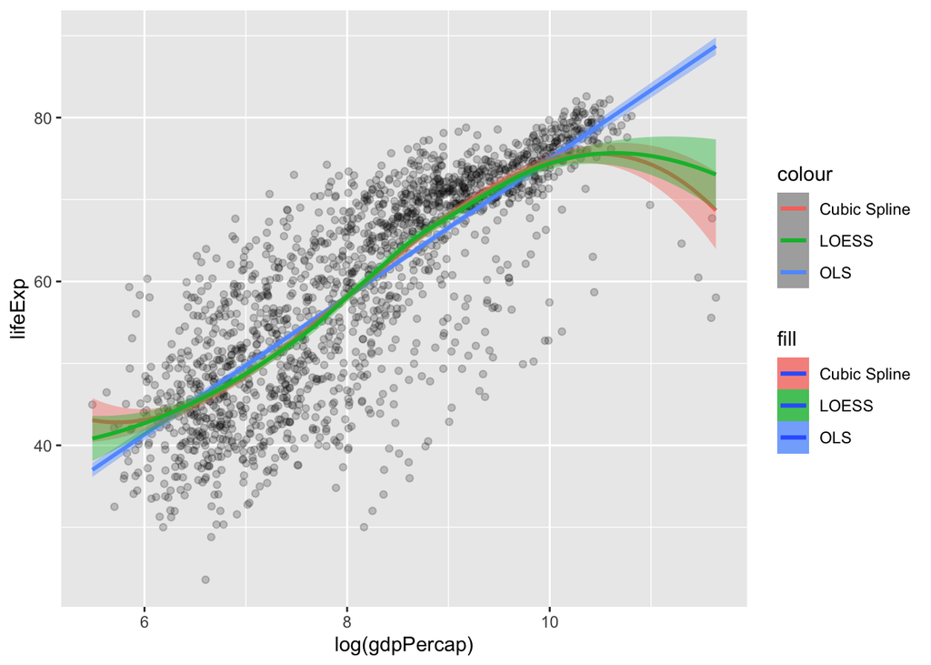

```r
#Layering geoms - Showing a legend
p0 <- ggplot(data = gapminder, mapping = aes(x = log(gdpPercap), y = lifeExp))
p1 <- p0 + geom_point(alpha = 0.2) +
  geom_smooth(method = "lm", aes(color = "OLS", fill = "OLS")) +
  geom_smooth(method = "lm", formula = y ~ splines::bs(x, df = 3), aes(color = "Cubic Spline", fill = "Cubic Spline")) +
  geom_smooth(method = "loess", aes(color = "LOESS", fill = "LOESS"))
p1
```

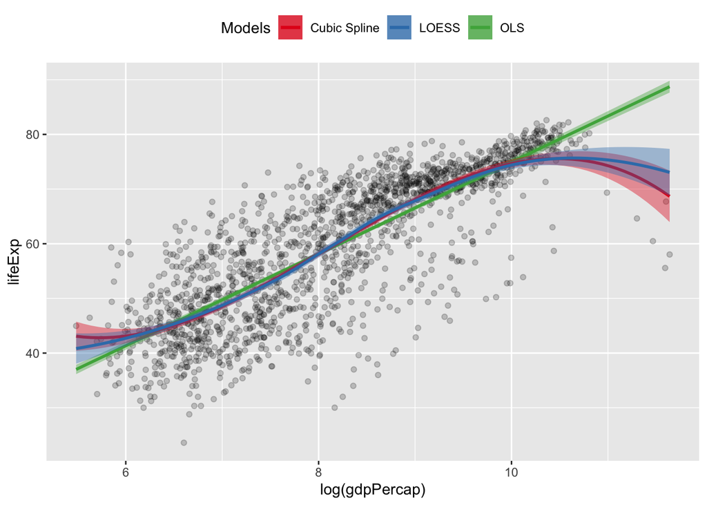

```r
##make legend pretty
#layering geoms - showing a legend
#assigning a colour from our model_colors palette to each of our model variables
p1 + scale_color_manual(name = "Models", values = model_colors) + scale_fill_manual(name = "Models", values = model_colors) + theme(legend.position = "top")
```

```r
gapminder
```

```
## # A tibble: 1,704 × 6
##    country     continent  year lifeExp      pop gdpPercap
##    <fct>       <fct>     <int>   <dbl>    <int>     <dbl>
##  1 Afghanistan Asia       1952    28.8  8425333      779.
##  2 Afghanistan Asia       1957    30.3  9240934      821.
##  3 Afghanistan Asia       1962    32.0 10267083      853.
##  4 Afghanistan Asia       1967    34.0 11537966      836.
##  5 Afghanistan Asia       1972    36.1 13079460      740.
##  6 Afghanistan Asia       1977    38.4 14880372      786.
##  7 Afghanistan Asia       1982    39.9 12881816      978.
##  8 Afghanistan Asia       1987    40.8 13867957      852.
##  9 Afghanistan Asia       1992    41.7 16317921      649.
## 10 Afghanistan Asia       1997    41.8 22227415      635.
## # … with 1,694 more rows
```

```r
str(gapminder)
```

```
## tibble [1,704 × 6] (S3: tbl_df/tbl/data.frame)
##  $ country  : Factor w/ 142 levels "Afghanistan",..: 1 1 1 1 1 1 1 1 1 1 ...
##  $ continent: Factor w/ 5 levels "Africa","Americas",..: 3 3 3 3 3 3 3 3 3 3 ...
##  $ year     : int [1:1704] 1952 1957 1962 1967 1972 1977 1982 1987 1992 1997 ...
##  $ lifeExp  : num [1:1704] 28.8 30.3 32 34 36.1 ...
##  $ pop      : int [1:1704] 8425333 9240934 10267083 11537966 13079460 14880372 12881816 13867957 16317921 22227415 ...
##  $ gdpPercap: num [1:1704] 779 821 853 836 740 ...
```

```r
#create the linear model object
out <- lm(formula = lifeExp ~ gdpPercap + pop + continent, data = gapminder)
out
```

```
##
## Call:
## lm(formula = lifeExp ~ gdpPercap + pop + continent, data = gapminder)
##
## Coefficients:
##       (Intercept)          gdpPercap                pop  continentAmericas
##         4.781e+01          4.495e-04          6.570e-09          1.348e+01
##     continentAsia    continentEurope   continentOceania
##         8.193e+00          1.747e+01          1.808e+01
```

```r
str(out)
```

[output not shown]

[output cut: 9 more lines]

[output not shown]

```r
summary(out)
```

```
##
## Call:
## lm(formula = lifeExp ~ gdpPercap + pop + continent, data = gapminder)
##
## Residuals:
##     Min      1Q  Median      3Q     Max
## -49.161  -4.486   0.297   5.110  25.175
##
## Coefficients:
##                    Estimate Std. Error t value Pr(>|t|)
## (Intercept)       4.781e+01  3.395e-01 140.819  < 2e-16 ***
## gdpPercap         4.495e-04  2.346e-05  19.158  < 2e-16 ***
## pop               6.570e-09  1.975e-09   3.326 0.000901 ***
## continentAmericas 1.348e+01  6.000e-01  22.458  < 2e-16 ***
## continentAsia     8.193e+00  5.712e-01  14.342  < 2e-16 ***
## continentEurope   1.747e+01  6.246e-01  27.973  < 2e-16 ***
## continentOceania  1.808e+01  1.782e+00  10.146  < 2e-16 ***
## ---
## Signif. codes:  0 '***' 0.001 '**' 0.01 '*' 0.05 '.' 0.1 ' ' 1
##
## Residual standard error: 8.365 on 1697 degrees of freedom
## Multiple R-squared:  0.5821, Adjusted R-squared:  0.5806
## F-statistic: 393.9 on 6 and 1697 DF,  p-value: < 2.2e-16
```

#predict()

```r
#make dataframe for predictions
min_gdp <- min(gapminder$gdpPercap)
max_gdp <- max(gapminder$gdpPercap)
med_pop <- median(gapminder$pop)
pred_df <- expand.grid(gdpPercap = (seq(from = min_gdp, to = max_gdp, length.out = 100)), pop = med_pop,
                       continent = c("Africa", "Americas", "Asia", "Europe", "Oceania"))
```

```r
dim(pred_df)
```

```
## [1] 500   3
```

```r
##make the prediction
pred_out <- predict(object = out, newdata = pred_df, interval = "predict")
head(pred_out)
```

```
##        fit      lwr      upr
## 1 47.96863 31.54775 64.38951
## 2 48.48298 32.06231 64.90365
## 3 48.99733 32.57670 65.41797
## 4 49.51169 33.09092 65.93245
## 5 50.02604 33.60497 66.44711
## 6 50.54039 34.11885 66.96193
```

```r
#binding our dataframe
pred_df <- cbind(pred_df, pred_out)
head(pred_df)
```

```
##   gdpPercap     pop continent      fit      lwr      upr
## 1  241.1659 7023596    Africa 47.96863 31.54775 64.38951
## 2 1385.4282 7023596    Africa 48.48298 32.06231 64.90365
## 3 2529.6905 7023596    Africa 48.99733 32.57670 65.41797
## 4 3673.9528 7023596    Africa 49.51169 33.09092 65.93245
## 5 4818.2150 7023596    Africa 50.02604 33.60497 66.44711
## 6 5962.4773 7023596    Africa 50.54039 34.11885 66.96193
```

```r
str(pred_df)
```

```
## 'data.frame':    500 obs. of  6 variables:
##  $ gdpPercap: num  241 1385 2530 3674 4818 ...
##  $ pop      : num  7023596 7023596 7023596 7023596 7023596 ...
##  $ continent: Factor w/ 5 levels "Africa","Americas",..: 1 1 1 1 1 1 1 1 1 1 ...
##  $ fit      : num  48 48.5 49 49.5 50 ...
##  $ lwr      : num  31.5 32.1 32.6 33.1 33.6 ...
##  $ upr      : num  64.4 64.9 65.4 65.9 66.4 ...
```

##As an example, we can create a visualization to explore our question “How does per capita GDP affect life expectancy in Europe and Africa?”

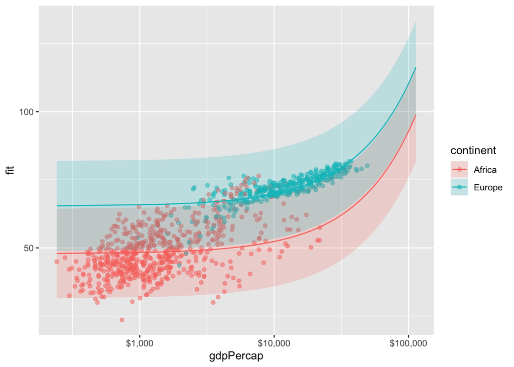

```r
p <- ggplot(data = subset(pred_df, continent %in% c("Europe", "Africa")), aes(x = gdpPercap, y = fit, ymin = lwr, ymax = upr, color = continent, fill = continent, group = continent))
p + geom_point(data = subset(gapminder, continent %in% c("Europe", "Africa")),
               aes(x = gdpPercap,
                   y = lifeExp, color = continent),
               alpha = 0.5, inherit.aes = FALSE) +
  geom_line() +
  geom_ribbon(alpha = 0.2, color = FALSE) + #alpha will show the transparent
  scale_x_log10(labels = scales::dollar)
```

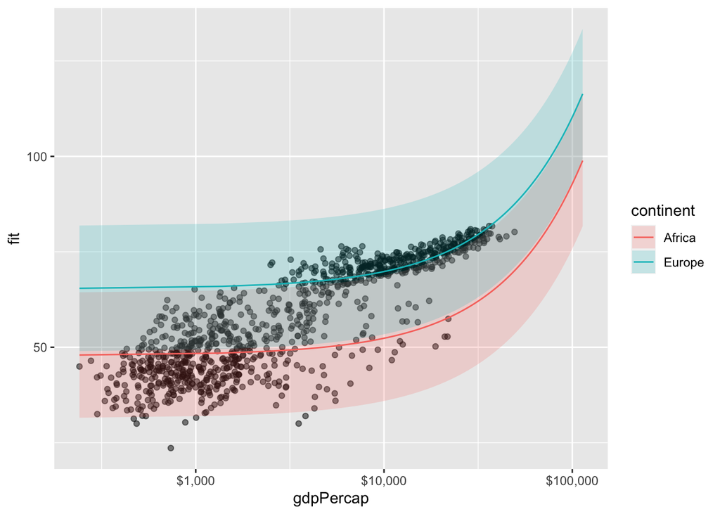

```r
p <- ggplot(data = subset(pred_df, continent %in% c("Europe", "Africa")), aes(x = gdpPercap, y = fit, ymin = lwr, ymax = upr, color = continent, fill = continent, group = continent))
p + geom_point(data = subset(gapminder, continent %in% c("Europe", "Africa")),
               aes(x = gdpPercap,
                   y = lifeExp), #remove color = continent
               alpha = 0.5, inherit.aes = FALSE) +
  geom_line() +
  geom_ribbon(alpha = 0.2, color = FALSE) + #alpha will show the transparent
  scale_x_log10(labels = scales::dollar)
```

How does per capita GDP affect fit(life expectancy) in Asia?

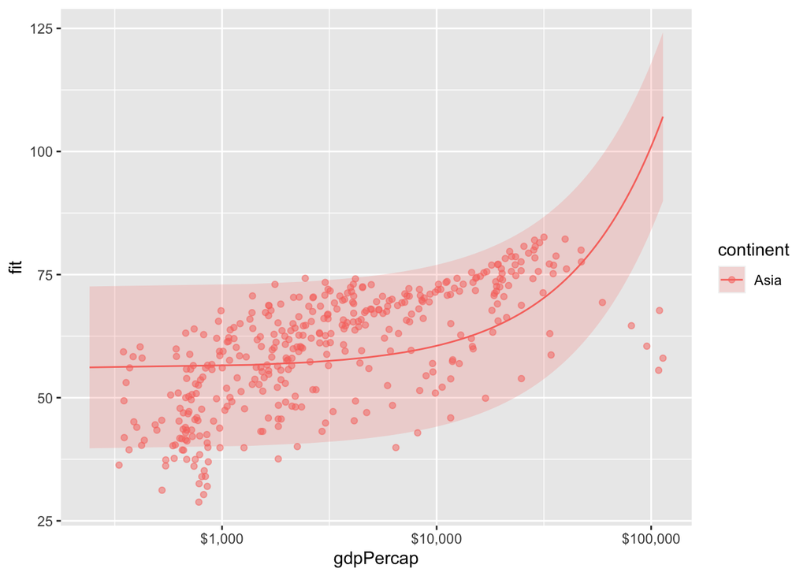

```r
p_asia <- ggplot(data = subset(pred_df, continent %in% ("Asia")), aes(x = gdpPercap, y = fit, ymin = lwr, ymax = upr, color = continent, fill = continent, group = continent))
p_asia + geom_point(data = subset(gapminder, continent %in% ("Asia")),
               aes(x = gdpPercap,
                   y = lifeExp, color = continent),
               alpha = 0.5, inherit.aes = FALSE) +
  geom_line() +
  geom_ribbon(alpha = 0.2, color = FALSE) + #alpha will show the transparent
  scale_x_log10(labels = scales::dollar)
```

```r
#install.packages("broom")
library(broom)
```

```r
out_conf <- tidy(out)
out_conf |> round_df()
```

```
## # A tibble: 7 × 5
##   term              estimate std.error statistic p.value
##   <chr>                <dbl>     <dbl>     <dbl>   <dbl>
## 1 (Intercept)          47.8       0.34    141.         0
## 2 gdpPercap             0         0        19.2        0
## 3 pop                   0         0         3.33       0
## 4 continentAmericas    13.5       0.6      22.5        0
## 5 continentAsia         8.19      0.57     14.3        0
## 6 continentEurope      17.5       0.62     28.0        0
## 7 continentOceania     18.1       1.78     10.2        0
```

Component level statistics with tidy() Now we can create a data visualization from this dataframe, the way that we have been doing all along

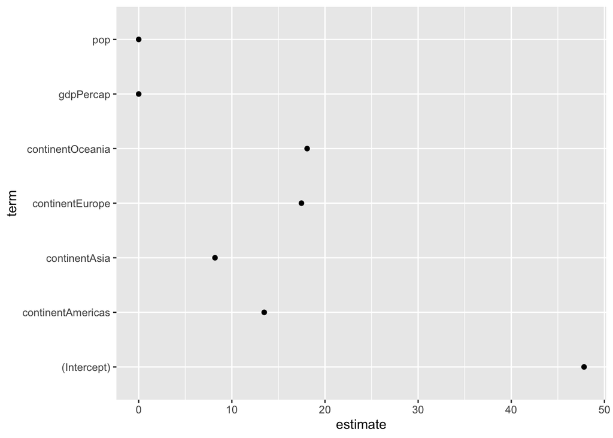

```r
p <- ggplot(out_conf, mapping = aes(x = term, y = estimate))
p + geom_point() + coord_flip()
```

The tidy() function takes a model object and returns a dataframe of component level information - For example, with an added step to round numeric columns to two decimal places:

```r
out_conf <- tidy(out)
out_conf |> round_df() # make it round number
```

```
## # A tibble: 7 × 5
##   term              estimate std.error statistic p.value
##   <chr>                <dbl>     <dbl>     <dbl>   <dbl>
## 1 (Intercept)          47.8       0.34    141.         0
## 2 gdpPercap             0         0        19.2        0
## 3 pop                   0         0         3.33       0
## 4 continentAmericas    13.5       0.6      22.5        0
## 5 continentAsia         8.19      0.57     14.3        0
## 6 continentEurope      17.5       0.62     28.0        0
## 7 continentOceania     18.1       1.78     10.2        0
```

plot the results

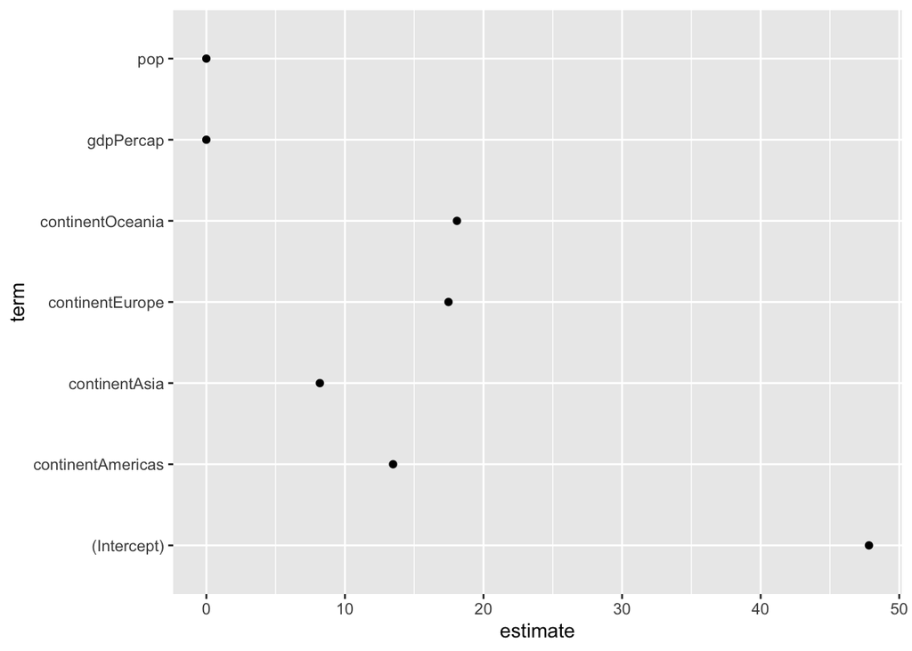

```r
p <- ggplot(out_conf, mapping = aes(x = term, y = estimate))
p + geom_point() + coord_flip()
```